# 1.4.2 Numpy 자료형

- 배열형 데이터를 입력으로 받는다.
- 배열의 모든 원소는 동일한 데이터 타입이여야 함.

```python
import numpy as np

x = np.array([[1,2,3],[4,5,6]])
print("x:\n{}".format(x))
print("x:\n", x)
```

```
x:
[[1 2 3]
 [4 5 6]]
x:
 [[1 2 3]
 [4 5 6]]
```

# 1.4.3 SciPy

- 고성능 선형 대수, 함수 최적화, 신호 처리, 특수한 수학 함수, 통계 분포
- scipy.sparse : 희소 행렬 기능 제공

```python
from scipy import sparse

# 대각선 원소는 1이고 나머지는 0인 2차원 Numpy 배열을 만든다
# np.eye() 함수를 사용하면 대각성분은 '1'이고 나머지 성분은 '0'으로 구성된 정방행렬인 단위행렬(unit matrix) 생성
eye = np.eye(4)
print("Numpy 배열 : \n{}".format(eye))
```

```
Numpy 배열 :
[[1. 0. 0. 0.]
 [0. 1. 0. 0.]
 [0. 0. 1. 0.]
 [0. 0. 0. 1.]]
```

```python
sparse_matrix = sparse.csr_matrix(eye)
print("Scipy의 CST 행렬:\n{}".format(sparse_matrix))
```

```
Scipy의 CST 행렬:
  (0, 0)	1.0
  (1, 1)	1.0
  (2, 2)	1.0
  (3, 3)	1.0
```

```python
# zeros()는 해당 배열에 모두 0을 집어 넣고, ones()는 모두 1을 집어 넣는다.
data = np.ones(4)
data
```

```
array([1., 1., 1., 1.])
```

```python
# arange 명령은 NumPy 버전의 range 명령이라고 볼 수 있다. 특정한 규칙에 따라 증가하는 수열을 만든다.
row_indices = np.arange(4)
col_indices = np.arange(4)
eye_coo = sparse.coo_matrix((data, (row_indices, col_indices)))
print("COO 표현:\n{}".format(eye_coo))
print("\nCOO 표현: \n", eye_coo) # 삐뚤어지게 나옴
```

```
COO 표현:
  (0, 0)	1.0
  (1, 1)	1.0
  (2, 2)	1.0
  (3, 3)	1.0

COO 표현:
   (0, 0)	1.0
  (1, 1)	1.0
  (2, 2)	1.0
  (3, 3)	1.0
```

# 1.4.4 Matplotlib

- 산점도, 히스토그램, 선그래프와 같은 과학 계산용 그래프 라이브러리

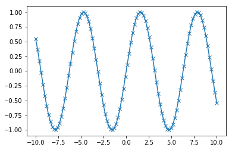

```python
%matplotlib inline
import matplotlib.pyplot as plt

# -10에서 10까지 100개의 간격으로 나뉜 배열을 생성
x = np.linspace(-10, 10, 100)

# sin 함수를 사용하여 y 배열을 생성
y = np.sin(x)

# plot 함수로 한 배열의 값을 다른 배열에 대응해서 선 그래프 그림
plt.plot(x, y, marker = "x")
```

# 1.4.5 Pandas 자료형

- pandas는 DataFrame 이라는 데이터 구조를 기반!
- pandas의 모듈을 사용하려면 dataframe으로 변환 후 사용할 것!

```python
from IPython.display import display
import pandas as pd

# 회원 정보가 들어간 간단한 데이터셋 생성
data = {'Name': ["Jone", "Anna", "Peter", "Linda"],
       'Location' : ["New York", "Paris", "Berlin", "London"],
       'Age' : [24, 13, 53,33]}

data_pandas = pd.DataFrame(data)
display(data_pandas)
```

|  | Name | Location | Age |
| --- | --- | --- | --- |
| 0 | Jone | New York | 24 |
| 1 | Anna | Paris | 13 |
| 2 | Peter | Berlin | 53 |
| 3 | Linda | London | 33 |

```python
print(data_pandas[data_pandas.Age > 30])
```

```
    Name Location  Age
2  Peter   Berlin   53
3  Linda   London   33
```

# 1.7 붓꽃의 품좀 분류

- 클래스 : 출력될 수 있는 값(붓꽃의 종류)
- 레이블 : 특정 데이터 포인트에 대한 출력(기대출력)

```python
from IPython.display import display
import numpy as np
import matplotlib.pyplot as plt
import pandas as pd
import mglearn
```

```python
from sklearn.datasets import load_iris
iris_dataset = load_iris()

print("iris_dataset의 키 :", iris_dataset.keys())

print(iris_dataset['target_names'])
```

```
iris_dataset의 키 : dict_keys(['data', 'target', 'target_names', 'DESCR', 'feature_names', 'filename'])
['setosa' 'versicolor' 'virginica']
```

```python
type(iris_dataset['data'])   #numpy.ndarray 형태 -> 배열형태. 모두 동일한 데이터 타입을 갖음
```

```
numpy.ndarray
```

```python
iris_dataset['data'][:5] # 맨 처음 다섯 샘플의 특성값
```

```
array([[5.1, 3.5, 1.4, 0.2],
       [4.9, 3. , 1.4, 0.2],
       [4.7, 3.2, 1.3, 0.2],
       [4.6, 3.1, 1.5, 0.2],
       [5. , 3.6, 1.4, 0.2]])
```

```python
iris_dataset['target']
```

```
array([0, 0, 0, 0, 0, 0, 0, 0, 0, 0, 0, 0, 0, 0, 0, 0, 0, 0, 0, 0, 0, 0,
       0, 0, 0, 0, 0, 0, 0, 0, 0, 0, 0, 0, 0, 0, 0, 0, 0, 0, 0, 0, 0, 0,
       0, 0, 0, 0, 0, 0, 1, 1, 1, 1, 1, 1, 1, 1, 1, 1, 1, 1, 1, 1, 1, 1,
       1, 1, 1, 1, 1, 1, 1, 1, 1, 1, 1, 1, 1, 1, 1, 1, 1, 1, 1, 1, 1, 1,
       1, 1, 1, 1, 1, 1, 1, 1, 1, 1, 1, 1, 2, 2, 2, 2, 2, 2, 2, 2, 2, 2,
       2, 2, 2, 2, 2, 2, 2, 2, 2, 2, 2, 2, 2, 2, 2, 2, 2, 2, 2, 2, 2, 2,
       2, 2, 2, 2, 2, 2, 2, 2, 2, 2, 2, 2, 2, 2, 2, 2, 2, 2])
```

```python
iris_dataset['feature_names']
```

```
['sepal length (cm)',
 'sepal width (cm)',
 'petal length (cm)',
 'petal width (cm)']
```

```python
iris_dataset['DESCR'] # 상세설명
```

```
'.. _iris_dataset:\n\nIris plants dataset\n--------------------\n\n**Data Set Characteristics:**\n\n    :Number of Instances: 150 (50 in each of three classes)\n    :Number of Attributes: 4 numeric, predictive attributes and the class\n    :Attribute Information:\n        - sepal length in cm\n     …
```

```python
type(iris_dataset['target']) # 배열형태, 모두 동일한 데이터 타입을 갖음
```

```
numpy.ndarray
```

###### scikit-learn의 trian_test_split 함수 : 데이터 셋을 75%의 훈련셋과 25%의 테스트 세트를 만들어 줌

scikit-learn에서 데이터는 대문자 X로 표시하고, 레이블은 소문자 y로 표기

```python
from sklearn.model_selection import train_test_split
X_train, X_test, y_train, y_test = train_test_split(
    iris_dataset['data'], iris_dataset['target'], random_state = 0)
```

```python
print("X_train 크기 : {}".format(X_train.shape))
print("y_train 크기 : {}".format(y_train.shape))
print("X_test 크기 : {}".format(X_test.shape))
print("y_test 크기 : {}".format(y_test.shape))
```

```
X_train 크기 : (112, 4)
y_train 크기 : (112,)
X_test 크기 : (38, 4)
y_test 크기 : (38,)
```

###### pandas의 scatter plot 사용하기

- pandas는 dataframe의 구조를 받기때문에, 기존의 데이터형을 바꿔줘야함!

```python
type(X_train)
```

```
numpy.ndarray
```

```
array([[<matplotlib.axes._subplots.AxesSubplot object at 0x000000000B894D30>,
      dtype=object)
```

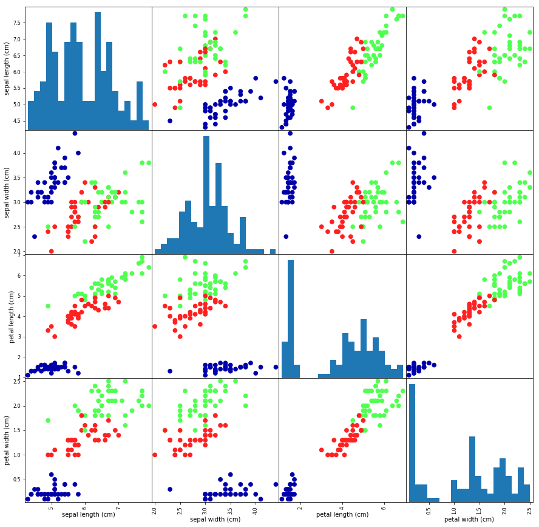

```python
# X_train 데이터를 사용해서 데이터 프레임을 만든다.
# 열의 이름은 iris_dataset.feature_names에 있는 문자열을 사용한다.
iris_dataframe = pd.DataFrame(X_train, columns = iris_dataset.feature_names)
# 데이터프레임을 사용해 y_train에 따라 색으로 구분된 산점도 행렬을 만든다.
pd.plotting.scatter_matrix(iris_dataframe, c=y_train, figsize=(15,15), marker='o',
                          hist_kwds={'bins': 20}, s=60, alpha = 8, cmap=mglearn.cm3)
```

# 1.7.4 K-NN, K-nearest Neighbors

1. 훈련데이터에서 새로운 데이터 포인트에 가장 가까운 'k개'의 이웃을 찾는다.
2. 이웃들의 클래스 중 빈도가 가장 높은 클래스를 예측값으로 사용

```python
# knn 객체는 훈련 데이터로 모델을 만들고 새로운 데이터 포인트에 대해 예측하는 알고리즘을 캡슐화
# 알고리즘이 훈련 데이터로부터 추출한 정보를 담고 있음.

from sklearn.neighbors import KNeighborsClassifier
knn = KNeighborsClassifier(n_neighbors = 1) #이웃의 개수를 1로
```

```python
# 훈련 데이터셋으로부터 모델을 만들려면 knn 객체의 fit메서드를 사용
# fit은 안에 Numpy 배열을 인수로 받음

knn.fit(X_train, y_train) # 모델 생성
```

```
KNeighborsClassifier(algorithm='auto', leaf_size=30, metric='minkowski',
           metric_params=None, n_jobs=None, n_neighbors=1, p=2,
           weights='uniform')
```

##### 1.7.5 예측하기

```python
X_new = np.array([[5, 2.9, 1, 0.2]])
print("X_new.shape: {}".format(X_new.shape))
```

```
X_new.shape: (1, 4)
```

```python
prediction = knn.predict(X_new)
print(prediction)
print(iris_dataset['target_names'][prediction])
```

```
[0]
['setosa']
```

클래스 0으로 예측 = 'setosa'

##### 1.7.6 모델평가

```python
y_pred = knn.predict(X_test)
print("테스트 셋에 대한 예측값\n {}".format(y_pred))
```

```
테스트 셋에 대한 예측값
 [2 1 0 2 0 2 0 1 1 1 2 1 1 1 1 0 1 1 0 0 2 1 0 0 2 0 0 1 1 0 2 1 0 2 2 1 0
 2]
```

```python
print("테스트 셋의 정확도: {:.2f}".format(np.mean(y_pred == y_test)))
```

```
테스트 셋의 정확도: 0.97
```

```python
print("테스트 셋의 정확도: {:.2f}".format(knn.score(X_test, y_test)))
```

```
테스트 셋의 정확도: 0.97
```

##### 1.7.8 요약 및 정리

- 분류문제에서 각 품종을 '클래스'라고 정의
- 개별 붓꽃의 품종은 '레이블'
- 붓꽃 데이터셋은 두 개의 Numpy 배열로 이루어짐
- X : 데이터를 담고 있음, 2차원 배열(각 데이터 포인트는 행. 각 특성은 열)
- y : 정확한 혹은 기대하는 출력을 갖음, 1차원 배열(각 샘플의 클래스 레이블에 해당하는 0 ~ 2값으로 구성)
- 모델구축에 사용할 훈련데이터 X_train, y_train
- 새로운 데이터에 얼마나 잘 적용할 수 있을지 평가하기 위한 테스트 세트 X_test, y_test
- KNN : 새 데이터 포인트를 예측하기 위해 훈련 데이터에서 가장 가까운 이웃 선택
- KNeighborsClassifier 클래스 -> 구현, 모델, 예측 가능